# Assignment 5: Medicaid Expansion and the Difference-in-differences Design

Part 1: Single Treatment Timing

Created by Harold Stolper and Frankie Michielli

2026-03-26

This lesson closely follows [Difference-in-Differences Designs: A Practitioner’s Guide](https://arxiv.org/abs/2503.13323) by Baker et al (2025).

#### Instructions: Write up your answers in the provided rmd file, make sure to maintain the same numbering in this document to ensure proper credit for your responses. Your submission should include: *(1) all R code and output you used to answer each question in your document;* and **(2) written answers to each question along with your reasoning.**

#### Unlike previous assignments with **pdf** submissions, for this one you will **submit an html file** knit from an rmd file, along with the rmd file.

#### **This means you can work directly from this rmd file rather than from a separate R script**. After installing any necessary packages, start by test knitting the rmd file with the assignment questions as an html file. As you work through the assignment, modify/add code chunks as necessary and add your write up. Remember to test knit frequently as you add code. To more easily explore the data without knitting, you will also need to run all of the code such that the output appears in your current environment in the upper right hand panel (and not just your knitting environment). To do this, click the green play button at the top of every code chunk as you go.

#### You will also need to install several any new packages listed below in order to knit this document, namely `did`, `HonestDID` and `latex2exp`.

```r
library(tidyverse)
library(kableExtra)
library(modelsummary)
library(did)
library(fixest)
library(HonestDiD)
library(latex2exp)
#library(gt)
#library(ggthemes)
```

# A Note on Research Design

Before we proceed, let’s talk briefly about research design. Think back to Quant II, where we focused on using Ordinary Least Squares to generate estimates of a parameter from a population regression function (PRF). We wrestled with the conditions that needed to hold for the parameter estimate to represent an unbiased effect of the explanatory variable of interest on the outcome variable.

Now let’s think more carefully about the target parameter we would like to estimate. We can actually think about different causal parameters, sometimes referred to as *estimands*; for example, the average treatment effect for the entire population (ATE), or, more narrowly, the average treatment effect on the treated (ATT). Of course for any individual entity, we never observe the outcome under both a treated and untreated state. This is the fundamental challenge with causal inference: we never observe the counterfactual! So we need a plan to mimic the counterfactual for some individual entities and arrive at an unbiased estimate of a causal parameter.

This is what we are doing with research design: research design is really just a strategy and set of assumptions to identify and estimate a target parameter for a given set of data. This lesson will help us understand a specific research design that is quite common: identifying and estimating the ATT of a binary treatment that has a staggered rollout across entities—the staggered difference-in-difference (DID) design. However, Part 1 will develop the framework under a simpler DID design with a single treatment date for all treated units, not a staggered rollout.

# 1 Introduction

In this lesson we will explore the same causal question with same data as Baker et al (2025): How did the expansion of public health insurance in the United States (Medicaid) under the Affordable Care Act (ACA) affect mortality?

Medicaid is a long-running federal and state program that provides free or low-cost healthcare to Americans with limited income and resources. The ACA, signed in 2010, is a health care reform law designed to make healthcare more affordable. One provision of the ACA enabled states, starting in 2014, to raise the Medicaid income eligibility threshold and reach relatively higher income households.

Medicaid expansion across the states showcases a staggered treatment adoption: despite a mandate by the ACA in 2014 that all states expand Medicaid eligibility to adults with incomes up to 138% of the federal poverty threshold, the Supreme Court made Medicaid expansion optional. Many states chose to expand Medicaid after 2014, but several states still did not so as of 2024. States chose to expand or not expand Medicaid due to a variety of economic and political considerations (Sommers and Epstein, 2013), resulting in observable differences between expansion and non-expansion states.

```r
# load cleaned data
load('bakeretal_cleaned.rdata')

# set seed for reproducibility
set.seed(20240924)
```

## 1.1 QUESTION: Using the `adopt` variable, report the adoption year by state.

Variation in medication expansion dates is summarized in the following table:

```r
# first get the share of states, share of counties, and share of adults in 2013 by adoption category
# first the states and share of states
states <- mydata %>%
  select(state, adopt) %>%
  distinct() %>%
  arrange(state) %>%
  group_by(adopt) %>%
  summarize(states = paste0(state, collapse = ", "),
            state_share = length(state) / 50)

# next get the county share and the population share
counties_pop <- mydata %>%
  # just for year 2013
  filter(year == 2013) %>%
  # get county and population totals
  mutate(total_counties = n(),
         total_pop = sum(population_20_64, na.rm = TRUE)) %>%
  group_by(adopt) %>%
  # make into shares
  summarize(county_share = n() / mean(total_counties),
            pop_share = sum(population_20_64, na.rm = TRUE) / mean(total_pop))

# make a table and export
states %>%
  left_join(counties_pop, by = "adopt") %>%
  slice(9, 1:8) %>%
  # format the numbers to two digits
  mutate(across(state_share:pop_share, ~ scales::number(., accuracy = 0.01))) %>%
  # format the table
  kable(
    col.names = c("Expansion Year", "States", "Share of States", "Share of Counties",
                  "Share of Adults (2013)"),
    booktabs = T, caption = "Medicaid Expansion Under the Affordable Care Act",
    align = c("c"),
    escape = FALSE,
    linesep = "",
    format = "html"
  ) %>%
  kable_styling(latex_options = c("scale_down", "HOLD_position")) %>%
  column_spec(2, width = "20em")
```

Table 1.1: Medicaid Expansion Under the Affordable Care Act

| Expansion Year | States | Share of States | Share of Counties | Share of Adults (2013) |
| --- | --- | --- | --- | --- |
| Pre-2014 | DE, MA, NY, VT | 0.08 | 0.03 | 0.09 |
| 2014 | AR, AZ, CA, CO, CT, HI, IA, IL, KY, MD, MI, MN, ND, NH, NJ, NM, NV, OH, OR, RI, WA, WV | 0.44 | 0.36 | 0.45 |
| 2015 | AK, IN, PA | 0.06 | 0.06 | 0.06 |
| 2016 | LA, MT | 0.04 | 0.04 | 0.02 |
| 2019 | ME, VA | 0.04 | 0.05 | 0.03 |
| 2020 | ID, NE, UT | 0.06 | 0.04 | 0.02 |
| 2021 | MO, OK | 0.04 | 0.06 | 0.03 |
| 2023 | NC, SD | 0.04 | 0.05 | 0.03 |
| Non-Expansion | AL, FL, GA, KS, MS, SC, TN, TX, WI, WY | 0.20 | 0.31 | 0.26 |

This is a good opportunity to see the importance of weighting in action. So far we have talked about the importance of using weights (such as sampling weights or important weights) to make statistics representative of a particular population. But we can also think about the choice of weights as a decision about how to average estimated effects between groups. California, for example, represented just 4.5% of the states that expanded Medicaid in 2014, 5.4% of the counties, but 27.7% of the adults ages 20-64. Thus its contribution to the average outcome for the 2014 expansion group is very different when weighting by adult population.

The outcome variable is the crude adult mortality rate, $Y_{it}$, for people ages 20-64 (measured per 100,000) by county (*i*) from 2009 to 2019 released by the Centers for Disease Control and Prevention (2024). The weighting variable is county *i*’s adult population in 2013, denoted by $W_i$, and socioeconomic covariates in year *t* are denoted by $X_{it}$. Table 1 defines the treatment group variable $G_i$ equal to the year in which county *i*’s state expanded Medicaid. The final sample contains 2,604 counties in states with complete data on mortality rates from 2009 to 2019 and covariates for 2013 and 2014.

Now that we have described the setup and data, we have to think about our empirical strategy and the comparisons we want to make. Which treatment groups in Table 1 should be compared with each other, over what time horizons? What conditions must hold in order for those comparisons to identify causal effects? How can we check if these conditions are empirically plausible and assess robustness to violations of these conditions?

# 2 $2 \times 2$ DID designs

In Quant II, you learned the DID method from the Card and Krueger (1995) minimum wage study. This is an example of the the $2 \times 2$ DID design, with two time periods (before and after the treatment) and two groups that are untreated in the first period but vary in their treatment exposure during the second period. To fix ideas, in this Medicaid example we will focus on comparing the 2014 expansion group of counties to the non-expansion group in 2013 and in 2014. We can think of this $2 \times 2$ design as the building block of more complex designs. With this $2 \times 2$ design, we can define a causal parameter for our treatment variable, the average effect of the treatment on the treated for 2014 expansion states, denoted $ATT(2014)$, along with the identifying assumption necessary for a particular estimation approach to generate an unbiased estimate of this causal parameter. Note that the *weighted* $ATT(2014)$ answers the question of “what was the average causal effect of Medicaid expansion on 2014 mortality rates *among adults in counties in states that expanded Medicaid in 2014*?” For comparison, the unweighted $ATT(2014)$ answers the question, “what was the average causal effect of Medicaid expansion on 2014 mortality rates *among the 2014 expansion state counties*?”

The identifying assumption here is the known as the *parallel trends assumption*: in the absence of treatment, the change in average outcomes for the expansion counties (the counterfactual) would be the same as for the non-expansion counties.

The estimation approach for this causal parameter under the parallel trends assumption is the familiar difference in the before-after differences for the 2014 expansion group and the non-expansion group:

$$\begin{align}
\hat{ATT}(2014) = (\bar{Y}_{D_i = 1, t = 2014} - \bar{Y}_{D_i = 1, t = 2013}) -
(\bar{Y}_{D_i = 0, t = 2014} - \bar{Y}_{D_i = 0, t = 2013}) \tag{2.1}
\end{align}$$

where $D_i$ indicates whether a county is located in a 2014 expansion state, and weights are suppressed for notational ease. Parallel trends requires the counterfactual change in outcomes for the treatment group (expansion counties), to be equal to the observed change in outcomes for the comparison group (non-expansion counties) given by the latter difference in the above expression.

Use the following code to create a table showing the DID estimates, both unweighted and population-weighted:

```r
# set the covariates that we're going to use.
covs <- c("perc_female","perc_white", "perc_hispanic", "unemp_rate", "poverty_rate", "median_income")

## Clean data and add in covariates
mydata <- mydata %>%
  # make variables
  mutate(perc_white = population_20_64_white / population_20_64 * 100,
         perc_hispanic = population_20_64_hispanic / population_20_64 * 100,
         perc_female = population_20_64_female/ population_20_64 * 100,
         unemp_rate = unemp_rate * 100,
         median_income = median_income / 1000) %>%
  # keep just subset of variables that we will use later
  select(state, county, county_code, year, population_20_64, adopt, yaca,
         starts_with("perc_"), crude_rate_20_64, all_of(covs))

# keep only counties with full observations for outcome and covariates in 2013 and 2014
mydata <- mydata %>%
  # allow the aca expansion variable to be missing
  drop_na(!yaca) %>%
  group_by(county_code) %>%
  # need full covariates for 2013 and 2014
  filter(length(which(year == 2013 | year == 2014)) == 2) %>%
  ungroup()

# finally, keep only counties with full mortality data for 2009 to 2019
mydata <- mydata %>%
  group_by(county_code) %>%
  drop_na(crude_rate_20_64) %>%
  filter(n() == 11)

# make a smaller dataset with only years 2013 and 2014
short_data <- mydata %>%
  # make a binary variable that identifies ACA expansion and post-years
  mutate(Treat = if_else(yaca == 2014 & !is.na(yaca), 1, 0),
         Post = if_else(year == 2014, 1, 0)) %>%
  # filter years for just 2013 and 2014
  filter(year %in% c(2013, 2014)) %>%
  # make a variable with population weight in 2013
  group_by(county_code) %>%
  mutate(set_wt = population_20_64[which(year == 2013)]) %>%
  ungroup()

# get group means for Table 2
# unweighted expansion pre-reform
T_pre <- short_data %>%
  filter(Treat == 1 & year == 2013) %>%
  summarize(mean = mean(crude_rate_20_64)) %>%
  pull(mean)

# unweighted non-expansion pre-form
C_pre <- short_data %>%
  filter(Treat == 0 & year == 2013) %>%
  summarize(mean = mean(crude_rate_20_64)) %>%
  pull(mean)

# unweighted expansion post-reform
T_Post <- short_data %>%
  filter(Treat == 1 & year == 2014) %>%
  summarize(mean = mean(crude_rate_20_64)) %>%
  pull(mean)

# unweighted non-expansion post-reform
C_Post <- short_data %>%
  filter(Treat == 0 & year == 2014) %>%
  summarize(mean = mean(crude_rate_20_64)) %>%
  pull(mean)

# get the same group means but this time weighted
T_pre_weight <- short_data %>%
  filter(Treat == 1 & year == 2013) %>%
  summarize(mean = weighted.mean(crude_rate_20_64, w = set_wt)) %>%
  pull(mean)

C_pre_weight <- short_data %>%
  filter(Treat == 0 & year == 2013) %>%
  summarize(mean = weighted.mean(crude_rate_20_64, w = set_wt)) %>%
  pull(mean)

T_Post_weight <- short_data %>%
  filter(Treat == 1 & year == 2014) %>%
  summarize(mean = weighted.mean(crude_rate_20_64, w = set_wt)) %>%
  pull(mean)

C_Post_weight <- short_data %>%
  filter(Treat == 0 & year == 2014) %>%
  summarize(mean = weighted.mean(crude_rate_20_64, w = set_wt)) %>%
  pull(mean)

# function to do a reasonable rounding
g_round <- function(x, k) {format(round(x, k), nsmall = k)}

# make table and export
tribble(
  ~"", ~"Expansion", ~ "No Expansion", ~"Gap/DiD", ~"Expansion", ~"No Expansion", ~"Gap/DiD",
  "2013", as.character(g_round(T_pre, 1)), as.character(g_round(C_pre, 1)), as.character(g_round(T_pre - C_pre, 1)),
  as.character(g_round(T_pre_weight, 1)), as.character(g_round(C_pre_weight, 1)), as.character(g_round(T_pre_weight - C_pre_weight, 1)),
  "2014", as.character(g_round(T_Post, 1)), as.character(g_round(C_Post, 1)), as.character(g_round(T_Post - C_Post, 1)),
  as.character(g_round(T_Post_weight, 1)), as.character(g_round(C_Post_weight, 1)), as.character(g_round(T_Post_weight - C_Post_weight, 1)),
  "Trend/DiD", as.character(g_round(T_Post - T_pre, 1)), as.character(g_round(C_Post-C_pre, 1)),
  as.character(g_round((T_Post - T_pre) - (C_Post-C_pre), 1)),
  as.character(g_round(T_Post_weight - T_pre_weight, 1)), as.character(g_round(C_Post_weight-C_pre_weight, 1)),
  as.character(g_round((T_Post_weight - T_pre_weight) - (C_Post_weight-C_pre_weight), 1))
) %>%
  # format table
  kable(align = 'c',
        booktabs = T,
        escape = F,
        caption = "Simple 2 X 2 DiD",
        format = "html") %>%
  kable_styling() %>%
  row_spec(3, color = "BrickRed") %>%
  column_spec(c(1:3, 5:6), color = "black") %>%
  row_spec(3, italic = TRUE) %>%
  column_spec(c(4, 7), italic = TRUE) %>%
  add_header_above(c(" " = 1, "Unweighted Averages" = 3, "Weighted Averages" = 3))
```

Table 2.1: Simple 2 X 2 DiD

|  | Unweighted Averages Expansion | Unweighted Averages No Expansion | Unweighted Averages Gap/DiD | Weighted Averages Expansion | Weighted Averages No Expansion | Weighted Averages Gap/DiD |
| --- | --- | --- | --- | --- | --- | --- |
| 2013 | 411.6 | 464.3 | -52.7 | 316.1 | 375.5 | -59.4 |
| 2014 | 420.4 | 473.8 | -53.4 | 319.3 | 381.8 | -62.5 |
| Trend/DiD | 8.8 | 9.5 | -0.7 | 3.2 | 6.3 | -3.1 |

## 2.1 QUESTION: According to Table 2.1, what was the average treatment effect of Medicaid expansion on mortality in 2014 among *counties* that are part of an expansion state? (hint: look at the results of unweighted averages). By contrast, what was the average treatment effect on mortality in 2014 for the average *adult* in expansion states? Be explicit about the units.

The same result can be obtained as the (weighted) least squares estimate of $\beta_{2x2}$ from the following PRF:

$$Y_{it} = \beta_0 + \beta_1 1\{D_i = 1\} + \beta_2 1\{t = 2014\} + \beta^{2x2} (1\{D_i = 1\} \times 1\{t = 2014\}) + \epsilon_{it}$$

## 2.2 QUESTION: To see why $\hat{\beta}^{2x2} = \hat{ATT}(2014)$, write out the SRF for each of the four groups defined by the treatment ($D_i$) and year. Following the first mean below, fill in the rest to show that the following holds true:

$$\begin{align}
\hat{ATT}(2014) = (\bar{Y}_{D_i = 1, t = 2014} - \bar{Y}_{D_i = 1, t = 2013}) -
(\bar{Y}_{D_i = 0, t = 2014} - \bar{Y}_{D_i = 0, t = 2013}) = \hat{\beta}^{2x2}
\end{align}$$

- The sample average outcome in the post-period for the treatment group is $\bar{Y}_{D_i = 1, t = 2014} = \hat{\beta}_0 + \hat{\beta}_1 + \hat{\beta}_2 + \hat{\beta}^{2x2}$
- The sample average outcome in the pre-period for the treatment group is $\bar{Y}_{D_i = 1, t = 2013} = \text{FILL IN ANSWER}$
- The sample average outcome in the post-period for the comparison group is $\bar{Y}_{D_i = 0, t = 2014} = \text{FILL IN ANSWER}$
- The sample average outcome in the pre-period for the comparison group is $\bar{Y}_{D_i = 0, t = 2013} = \text{FILL IN ANSWER}$

## 2.3 QUESTION: What are the advantages to regression-based DID estimation as opposed to relying on differences in sample averages (as we did in Question 2.2)?

# 3 Incorporating covariates

There are a number of reasons to consider covariates $X_{it}$ in a DID design:

1. Checking for balance in variables that could influence the counterfactual outcome; if any relevant covariates are imbalanced, that would invalidate the parallel trends assumption;
2. Controlling for these relevant covariates; or
3. Estimating heterogeneous treatment effects.

For example, in the absence of Medicaid expansion, mortality rates likely would have evolved differently in poorer and richer counties, as they did before 2014 (Currie and Schwandt, 2016). Therefore, parallel trends may fail if poverty rates differ between expansion and non-expansion counties. If they do, then one may want to “control for” poverty rates when estimating ATT parameters.

## 3.1 QUESTION: Show only the mean values of each covariate in 2013 by year of adoption (by first filtering on `year == 2013`). Round to 1 decimal point. Note the average poverty rate in 2013 for counties that expanded in 2014 and non-expansion counties.

The parallel trends assumption cannot be formally tested, as the counterfactual is never observed. Thus any “test” of parallel trends is an indirect one that relies on other observed variables that could influence outcomes in the absence of the treatment (“untreated potential outcome trends”). In this case, demographic and economic conditions were strongly correlated with both mortality levels and mortality trends over time. Parallel trends would fail to hold if, for example, if county poverty rates were correlated with mortality levels and trends, and with expansion status. One way to evaluate parallel trends is to check for balance in observable determinants of potential outcomes such as poverty rates. Baker et al (2025) suggest using a normalized measure of imbalance that is comparable across variables with different underlying units and distributions: the normalized difference in means between the treatment and comparison groups (Imbens and Rubin, 2015, Chapter 14):

$$\text{Normalized difference} = \dfrac{\bar{X}_T - \bar{X}_C}{\sqrt{(S^2_T + S^2_C)/2}}$$
where $S^2_T$ and $S^2_C$ are the sample weighted variances of the covariates for the treatment and comparison group. Baker et al (2025) recommend following the general rule of thumb that values of the normalized difference in excess of 0.25 in absolute value indicate a potentially problematic imbalance between the two groups (Imbens and Rubin, 2015, page 277).

## 3.2 QUESTION: Using the formula above, calculate the normalized difference in unweighted median income between treatment and comparison groups for the year 2013 from `short_data`. Round to 2 decimal points. Is it above the 0.25 rule of thumb and suggestive of problematic imbalance?

## 3.3 QUESTION: Table 3.1 below reports the means and normalized difference in means for various covariates. The top panel reports the averages and standardized differences of each variable, measured in 2013, by adoption status. The bottom panel report the average and standardized differences of the county-level long differences between 2014 and 2013 of each variable. Looking at the top panel, which baseline measures appear to be meaningfully imbalanced? Looking at the bottom panel, which baseline imbalances changed from 2013 to 2014? What does this say about the parallel trends assumption?

```r
# Now, make the covariate balance table (Table 4).
# unweighted - pre
unweighted <- short_data %>%
  filter(year == 2013) %>%
  select(Treat, all_of(covs)) %>%
  group_by(Treat) %>%
  # get mean and standard deviation
  summarize_all(list(mean, var)) %>%
  # pivot the data longer
  pivot_longer(cols = !Treat,
               names_to = "variable",
               values_to = "value") %>%
  # now make separate columns for treated and untreated
  pivot_wider(names_from = "Treat",
              values_from = "value",
              names_prefix = "group") %>%
  # separate mean and standard deviations
  extract(variable, into = c("variable", "fx"), "(.*)_(.*)") %>%
  pivot_wider(id_cols = variable,
              names_from = fx,
              values_from = c(group0, group1)) %>%
  # make normalized difference
  mutate(norm_diff = (group1_fn1 - group0_fn1)/sqrt((group1_fn2 + group0_fn2)/2)) %>%
  select(variable, group0_fn1, group1_fn1, norm_diff)

# make a weighted variance function
wtd.var <- function (x, weights = NULL, normwt = FALSE, na.rm = TRUE,
                     method = c("unbiased", "ML"))
{
  method <- match.arg(method)
  if (!length(weights)) {
    if (na.rm)
      x <- x[!is.na(x)]
    return(var(x))
  }
  if (na.rm) {
    s <- !is.na(x + weights)
    x <- x[s]
    weights <- weights[s]
  }
  if (normwt)
    weights <- weights * length(x)/sum(weights)
  if (normwt || method == "ML")
    return(as.numeric(stats::cov.wt(cbind(x), weights, method = method)$cov))
  sw <- sum(weights)
  if (sw <= 1)
    warning("only one effective observation; variance estimate undefined")
  xbar <- sum(weights * x)/sw
  sum(weights * ((x - xbar)^2))/(sw - 1)
}

# weighted  - pre
weighted <- short_data %>%
  filter(year == 2013) %>%
  select(Treat, all_of(covs), set_wt) %>%
  group_by(Treat) %>%
  # get mean and standard deviation
  summarize(across(all_of(covs),
                   list(
                     ~weighted.mean(x = ., w = set_wt),
                     ~wtd.var(x = ., weights = set_wt, normwt = TRUE)))) %>%
  # pivot the data longer
  pivot_longer(cols = !Treat,
               names_to = "variable",
               values_to = "value") %>%
  # now make separate columns for treated and untreated
  pivot_wider(names_from = "Treat",
              values_from = "value",
              names_prefix = "group") %>%
  # separate mean and standard deviations
  extract(variable, into = c("variable", "fx"), "(.*)_(.*)") %>%
  pivot_wider(id_cols = variable,
              names_from = fx,
              values_from = c(group0, group1)) %>%
  # make normalized difference
  mutate(norm_diff = (group1_1 - group0_1)/sqrt((group1_2 + group0_2)/2)) %>%
  select(variable, group0_1, group1_1, norm_diff)

# make the top panel (weighted and unweighted Pre)
top_panel <- bind_cols(unweighted, weighted %>% select(-variable))

# make the bottom panel, which is the same thing but with the difference in X between 2014 and 2013.
# unweighted
unweighted <- short_data %>%
  select(county_code, year, Treat, all_of(covs)) %>%
  arrange(county_code, year) %>%
  group_by(county_code, Treat) %>%
  summarize(
    across(all_of(covs), function(x) x[2] - x[1])
  ) %>%
  ungroup() %>%
  select(-county_code) %>%
  group_by(Treat) %>%
  # get mean and standard deviation
  summarize_all(list(mean, var)) %>%
  # pivot the data longer
  pivot_longer(cols = !Treat,
               names_to = "variable",
               values_to = "value") %>%
  # now make separate columns for treated and untreated
  pivot_wider(names_from = "Treat",
              values_from = "value",
              names_prefix = "group") %>%
  # separate mean and standard deviations
  extract(variable, into = c("variable", "fx"), "(.*)_(.*)") %>%
  pivot_wider(id_cols = variable,
              names_from = fx,
              values_from = c(group0, group1)) %>%
  # make normalized difference
  mutate(norm_diff = (group1_fn1 - group0_fn1)/sqrt((group1_fn2 + group0_fn2)/2)) %>%
  select(variable, group0_fn1, group1_fn1, norm_diff)

# weighted
weighted <- short_data %>%
  select(county_code, year, Treat, all_of(covs)) %>%
  arrange(county_code, year) %>%
  group_by(county_code, Treat) %>%
  summarize(
    across(all_of(covs), function(x) x[2] - x[1])
  ) %>%
  ungroup() %>%
  left_join(short_data %>% filter(year == 2013) %>% select(county_code, set_wt),
            join_by(county_code)) %>%
  select(-county_code) %>%
  group_by(Treat) %>%
  # get mean and standard deviation
  summarize(across(all_of(covs),
                   list(
                     ~weighted.mean(x = ., w = set_wt),
                     ~wtd.var(x = ., weights = set_wt, normwt = TRUE)))) %>%
  # pivot the data longer
  pivot_longer(cols = !Treat,
               names_to = "variable",
               values_to = "value") %>%
  # now make separate columns for treated and untreated
  pivot_wider(names_from = "Treat",
              values_from = "value",
              names_prefix = "group") %>%
  # separate mean and standard deviations
  extract(variable, into = c("variable", "fx"), "(.*)_(.*)") %>%
  pivot_wider(id_cols = variable,
              names_from = fx,
              values_from = c(group0, group1)) %>%
  # make normalized difference
  mutate(norm_diff = (group1_1 - group0_1)/sqrt((group1_2 + group0_2)/2)) %>%
  select(variable, group0_1, group1_1, norm_diff)

# make the bottom panel
bottom_panel <- bind_cols(unweighted, weighted %>% select(-variable))

# bind the two panels
table <- bind_rows(top_panel, bottom_panel) %>%
  # reformat all columns to two digits
  mutate(across(-variable, \(x) scales::comma(x, accuracy = 0.01)))

# format Table 4 and export
table %>%
  # change column names
  mutate(variable =
           case_match(variable,
                      "perc_female" ~ "% Female",
                      "perc_white" ~ "% White",
                      "perc_hispanic" ~ "% Hispanic",
                      "unemp_rate" ~ "Unemployment Rate",
                      "poverty_rate" ~ "Poverty Rate",
                      "median_income" ~ "Median Income")) %>%
  # format latex table
  kable(col.names = c("Variable", "Non-Adopt", "Adopt", "Norm. Diff.", "Non-Adopt", "Adopt", "Norm. Diff."),
        align = 'lcccccc',
        escape = T,
        booktabs = T,
        caption = "Covariate Balance Statistics",
        linesep = "",
        format = "html") %>%
  kable_styling(latex_options = c("scale_down", "hold_position")) %>%
  pack_rows("2013 Covariate Levels", 1, 6) %>%
  pack_rows("2014 - 2013 Covariate Differences", 7, 12) %>%
  add_header_above(c(" " = 1, "Unweighted" = 3, "Weighted" = 3))
```

Table 3.1: Covariate Balance Statistics

| Variable | Unweighted Non-Adopt | Unweighted Adopt | Unweighted Norm. Diff. | Weighted Non-Adopt | Weighted Adopt | Weighted Norm. Diff. |
| --- | --- | --- | --- | --- | --- | --- |
| **2013 Covariate Levels** |  |  |  |  |  |  |
| % Female | 49.41 | 49.38 | -0.01 | 50.44 | 50.23 | -0.12 |
| % White | 81.85 | 90.36 | 0.56 | 78.35 | 78.75 | 0.03 |
| % Hispanic | 8.16 | 8.10 | -0.01 | 14.36 | 18.32 | 0.24 |
| Unemployment Rate | 7.50 | 7.95 | 0.18 | 6.93 | 7.92 | 0.50 |
| Poverty Rate | 18.46 | 16.34 | -0.33 | 16.58 | 15.24 | -0.25 |
| Median Income | 44.33 | 48.46 | 0.34 | 50.78 | 58.52 | 0.55 |
| **2014 - 2013 Covariate Differences** |  |  |  |  |  |  |
| % Female | -0.02 | -0.02 | 0.00 | 0.01 | 0.01 | -0.03 |
| % White | -0.21 | -0.22 | -0.02 | -0.32 | -0.34 | -0.12 |
| % Hispanic | 0.19 | 0.21 | 0.09 | 0.24 | 0.32 | 0.31 |
| Unemployment Rate | -1.10 | -1.30 | -0.29 | -1.04 | -1.35 | -0.61 |
| Poverty Rate | -0.45 | -0.28 | 0.09 | -0.34 | -0.30 | 0.03 |
| Median Income | 1.00 | 1.16 | 0.07 | 1.14 | 1.70 | 0.28 |

## The conditional parallel trends assumption

Given the observed imbalance in covariates that could invalidate parallel trends, we can formulate a new conditional parallel trends assumption which states that parallel trends holds within each covariate specific stratum—combinations of discrete covariate values—rather than over the whole population. Given the results from Table 4, this amounts to assuming parallel trends in potential outcomes between expansion and non-expansion counties that in 2013 had the same female, white, and Hispanic shares, as well as the same unemployment and poverty rates and median income. This assumption does not restrict how potential outcomes changes in different covariate strata, it simply requires that covariate-specific trends are common between expansion and non-expansion counties.

We also need to observe both treated and untreated units for all covariate values (a “common support” assumption).

You can work through the math in the original paper, but the result is that under conditional parallel trends, common support, and a no anticipation (of the treatment) assumption, $ATT(2014)$ is equal to the path of outcomes experienced by the treated group minus the average path of outcomes in the comparison group for each value of the covariates, averaged over the treated group’s distribution of covariates.

## DID estimation with covariates: TWFE

The most common approach to estimating $ATT(2014)$ under conditional parallel trends is to simply add the covariates to the basic TWFE model:

$$\begin{align}
Y_{it} = \theta_t + \eta_i + \beta_{treat}D_{it} + X^{'}_{it} \beta_{covs} + \epsilon_{it} \tag{2.1}
\end{align}$$

```r
reg_data_2013 <- short_data %>%
  # make long diff in y
  group_by(county_code) %>%
  summarize(long_y = crude_rate_20_64[which(year == 2014)] - crude_rate_20_64[which(year == 2013)]) %>%
  # merge in 2013 covariates
  left_join(short_data %>% filter(year == 2013) %>% select(county_code, state, Treat, set_wt, all_of(covs)),
            by = "county_code")

# this dataset has the change in X between 2014 and 2013 as controls
reg_data_change <- short_data %>%
  # make long diff in y
  group_by(county_code) %>%
  summarize(long_y = crude_rate_20_64[which(year == 2014)] - crude_rate_20_64[which(year == 2013)]) %>%
  # merge in change in covariate values
  left_join(short_data %>%
              group_by(county_code) %>%
              mutate(set_wt = set_wt[which(year == 2013)]) %>%
              group_by(county_code, state, Treat, set_wt) %>%
              summarize(
                across(all_of(covs), function(x) x[which(year == 2014)] - x[which(year == 2013)])
              ), by = "county_code")
# run the six models
# first unweighted - long diff no covs, 2013 covs, then change in covs
mod1 <- feols(long_y ~ Treat, data = reg_data_2013, cluster = ~county_code)
mod2 <- feols(long_y ~ Treat + .[covs], data = reg_data_2013, cluster = ~county_code)
mod3 <- feols(long_y ~ Treat + .[covs], data = reg_data_change, cluster = ~county_code)

# same thing but weighted
mod4 <- feols(long_y ~ Treat, data = reg_data_2013, weights = ~set_wt, cluster = ~county_code)
mod5 <- feols(long_y ~ Treat + .[covs], data = reg_data_2013, weights = ~set_wt, cluster = ~county_code)
mod6 <- feols(long_y ~ Treat + .[covs], data = reg_data_change, weights = ~set_wt, cluster = ~county_code)
```

However, a TWFE specification can only account for differential trends related to baseline covariate levels if pre-treatment covariate values are interacted with a post-treatment dummy:

$$\begin{align}
Y_{it} = \theta_t + \eta_i + \beta_{treat,2}D_{it} + (1\{t = 2014\} X^{'}_{i,t=2013}) \beta_{covs,2} + \epsilon_{it} \tag{2.2}
\end{align}$$

Note the possibility of that of “bad controls” , whereby one or more of the covariates is affected by the treatment. If Medicaid expansion caused a reduction in poverty rates, for example, then including 2014 poverty rates or the 2013-2014 change in poverty rates as a covariate would introduce bias when estimating $ATT(2014)$ with TWFE. Hence the term $1\{t = 2014\} X^{'}_{i,t=2013}$ interacts *pre-treatment* covariates with a post-treatment dummy variable. However, weighting can introduce further bias (Sloczynski, 2022; Caetano and Callaway, 2024). Fortunately, there are other approaches to estimating $ATT(2014)$ under conditional parallel trends that do not rely on TWFE.

## DID estimators with covariates that target the $ATT(2014)$

One strategy is known as the regression-adjustment (RA) or outcome regression approach to DID. With this approach, *untreated outcome trends* as a function of the covariates $X_i$ are obtained by regressing the change in outcome on covariates for *untreated* units. The fitted model (SRF) is then used to generated predicted values of the change in outcomes for *all* units (treated as well as untreated). This is one approach to mimicking the counterfactual change in outcomes for treated units.

Another strategy is known as the inverse probability weighted (IPW) DID procedure. Following from the balance checks from Table 4, if imbalance in covariates is the source of parallel trends violations, then adjusting the comparison group to be balanced on covariates can address that bias. The adjustment takes the form of re-weighting the observed changes in adult mortality rates for non-expansion counties to ensure that the expansion and non-expansion counties are similar on covariates, thus addressing the compositional source of bias. IPW relies on estimating the probability of belonging to the treatment group conditional on covariates, known as the “propensity score.”

In practice, there are major advantages to combining both RA and IPW approaches in a way that leads to estimators for $ATT(2014)$ that are more robust against model misspecification; this is called the doubly robust (DR) approach (Sant’Anna and Zhao, 2020). Between RA, IPW, and DR DID estimators, Baker et al (2025) recommend that practitioners favor DR due to the added protection from model misspecification.

The preferred DR estimator for DID is commonly referred to as the Callaway and Sant’Anna (CS) estimator, which can be estimated using the `drdid` package in R.

## 3.4 QUESTION: Obtain the unweighted and weighted $ATT(2014)$ using the doubly robust Callaway and Sant’Anna (2021) estimator (CS). To do this, first run the code chunk below to prepare the `data_cs` data frame. Second, in the next code chunk, fill in the appropriate `est_method` argument in the two `att_gt()` function calls that allow for doubly robust esimation. Third, remove the code chunk option `{eval = FALSE}` in order to run the estimation code.

## Hint: use the help function `?att_gt` to help you determine the appropriate syntax for the doubly robust `est_method`.

```r
# finally, get the same estimates using Sant'Anna and Zhao (2020) and Callaway and Sant'Anna (2021) using the
# three adjustment methods
# First you need to reformat the group variable (untreated = 0) and the unit ID variable needs to be numeric
data_cs <- short_data %>%
  mutate(treat_year = if_else(yaca == 2014 & !is.na(yaca), 2014, 0),
         county_code = as.numeric(county_code))
```

```r
# remove eval = FALSE code chunk option in order to run this code!


# unweighted ATT using doubly robust (DR) method
att_gt(
    yname = "crude_rate_20_64",
    tname = "year",
    idname = "county_code",
    gname = "treat_year",
    xformla =  as.formula(paste("~", paste(covs, collapse = "+"))),
    data = data_cs,
    panel = TRUE,
    control_group = "nevertreated",
    bstrap = TRUE,
    cband = TRUE,
    est_method = FILL IN HERE,
    base_period = "universal",
    biters = 25000
  )

# weighted ATT using doubly robust (DR) method
att_gt(
    yname = "crude_rate_20_64",
    tname = "year",
    idname = "county_code",
    gname = "treat_year",
    xformla =  as.formula(paste("~", paste(covs, collapse = "+"))),
    data = data_cs,
    panel = TRUE,
    control_group = "nevertreated",
    bstrap = TRUE,
    cband = TRUE,
    est_method = FILL IN HERE,
    weightsname = "set_wt",
    base_period = "universal",
    biters = 25000
  )
```

The results from the three approaches (RA, IPW, and DR) are summarized in the following table, which reports unweighted and population-weighted 2x2 DID estimates comparing 978 counties in states that expand Medicaid in 2014 to 1,222 counties in states that did not expand Medicaid by 2019, adjusting for 2013 covariate values.

```r
# create a function to run the CS estimator allowing the estimation method to differ
run_cs <- function(method, wt) {

  # estimate the att_gt
  atts <- att_gt(
    yname = "crude_rate_20_64",
    tname = "year",
    idname = "county_code",
    gname = "treat_year",
    xformla =  as.formula(paste("~", paste(covs, collapse = "+"))),
    data = data_cs,
    panel = TRUE,
    control_group = "nevertreated",
    bstrap = TRUE,
    cband = TRUE,
    est_method = method,
    weightsname = wt,
    # faster_mode = TRUE,
    base_period = "universal",
    biters = 25000
  )

  # aggregate estimates
  aggte(atts, na.rm = TRUE, biters = 25000) %>%
    broom::tidy() %>%
    filter(group == 2014) %>%
    mutate(type = method)

}

# run it three ways - regression adjustment, IPW, and doubly robust
# these are unweighted
ests <- map_dfr(c("reg", "ipw", "dr"), run_cs, wt = NULL)

# make a table - Panel A is with unweighted models
tablea <- ests %>%
  # reformat the data
  select(type, estimate, std.error) %>%
  # format the estimate and std error
  mutate(estimate = scales::number(estimate, accuracy = 0.01),
         std.error = paste0("(", scales::number(std.error, accuracy = 0.01), ")")) %>%
  # reshape the data
  pivot_longer(cols = -type,
               names_to = "statistic",
               values_to = "value") %>%
  pivot_wider(id_cols = "statistic",
              names_from = "type",
              values_from = "value") %>%
  mutate(statistic = if_else(statistic == "estimate", "Medicaid Expansion", " "))

# make weighted results for the three CS models.
ests_w <-  map_dfr(c("reg", "ipw", "dr"), run_cs, wt = "set_wt")

# Panel B is the same thing but with weighted results
tableb <- ests_w %>%
  select(type, estimate, std.error) %>%
  mutate(estimate = scales::number(estimate, accuracy = 0.01),
         std.error = paste0("(", scales::number(std.error, accuracy = 0.01), ")")) %>%
  pivot_longer(cols = -type,
               names_to = "statistic",
               values_to = "value") %>%
  pivot_wider(id_cols = "statistic",
              names_from = "type",
              values_from = "value") %>%
  select(reg, ipw, dr)

# Combine Panels A and B together and format the table
bind_cols(tablea, tableb) %>%
  kable(col.names = c(" ", "Regression", "IPW", "Doubly Robust",
                      "Regression", "IPW", "Doubly Robust"),
        align = 'lcccccc',
        escape = F,
        booktabs = T,
        caption = "Callaway and Sant'Anna (2021) DiD",
        linesep = "",
        format = "html") %>%
  kable_styling(latex_options = c("hold_position")) %>%
  add_header_above(c(" " = 1, "Unweighted" = 3, "Weighted" = 3))
```

Table 3.2: Callaway and Sant’Anna (2021) DiD

|  | Unweighted Regression | Unweighted IPW | Unweighted Doubly Robust | Weighted Regression | Weighted IPW | Weighted Doubly Robust |
| --- | --- | --- | --- | --- | --- | --- |
| Medicaid Expansion | -2.05 | -1.98 | -2.36 | -2.98 | -2.15 | -3.92 |
|  | (3.93) | (3.89) | (4.10) | (1.75) | (2.53) | (2.93) |

## 3.5 QUESTION: Focusing on the weighted estimates in the table above, how do results change across the three approaches?

# 4 $2 \times T$ DID designs with multiple time periods (unstaggered)

The previous section developed identification strategies and estimation approaches for the $2 \times 2$ DID design—the building blocks of DID with more than two time periods. With $T > 2$ time periods there is an *ATT* in each treatment period that traces out treatment effect dynamics, as well as treated-untreated comparisons prior to the treatment that can inform the plausibility of parallel trends.

Here the term “event study” refers to the practice of estimating effects across multiple time periods before and after the treatment. Now we expand the analysis of the 2014 Medicaid expansion group to include data from 2009 to 2019 (but still only looking at counties that expanded in 2014 or not at all before 2019). We refer to the first treatment period as *g*, such that the base period just prior to the treatment will be *t = g - 1*.

## 4.1 QUESTION: First, run the code below to create `grouped_data`, which includes the weighted average of mortality rates by year by expansion group. Then, plot time series of the population-weighted morality rates for the 2014 expansion counties (treated) and post-2019 expansion counties (untreated comparison counties). Using `geom_vline()`, add a vertical line at 2014; this naturally divides the x-axis into two windows: post-treatment (2014-2019) and pre-treatment (2009-2013).

## HINT: inspect `grouped_data` before plotting.

```r
# make ACA and post variables, as well as the weighting variable which is the relevant county
# population in 2013
mydata <- mydata %>%
  # make state the abbreviation
  mutate(state = str_sub(county, nchar(county) - 1, nchar(county))) %>%
  # drop DC and pre-2014 adoption states
  filter(!(state %in% c("DC", "DE", "MA", "NY", "VT"))) %>%
  # drop states that adopt between 2014 and 2019
  filter(yaca == 2014 | is.na(yaca) | yaca > 2019) %>%
  mutate(Treat = if_else(yaca == 2014 & !is.na(yaca), 1, 0),
         Post = if_else(year >= 2014, 1, 0)) %>%
  group_by(county_code) %>%
  # make a variable with population weight in 2013
  mutate(set_wt = population_20_64[which(year == 2013)]) %>%
  ungroup()

grouped_data <- mydata %>%
  mutate(expand = if_else(Treat == 1, "Expansion Counties", "Non-Expansion Counties")) %>%
  # get the weighted averages by expansion type and year
  group_by(expand, year) %>%
  summarize(mortality = weighted.mean(crude_rate_20_64, set_wt))
```

## Event study estimates in the post-treatment periods

In the simple event study, the target parameters are the familiar $ATT(t)$’s from the $2 \times 2$ design, but now there are many more of them to identify, estimate, and interpret. But identifying each $ATT(t)$ requires parallel trends in every post-period, which we will refer to as the event study parallel trends assumption (Assumption PT-ES): in the absence of the treatment, the average change in outcomes for the treated group between period *t* and one period prior to the treatment (*g - 1*) is the same as for untreated group, for every post-treatment period $t$.

Learning about dynamic effects over more than two time periods thus requires stronger assumptions than the $2 \times 2$ case. In order to identify the average effect of Medicaid expansion in 2019 among expansion counties, Assumption PT-ES requires parallel trends to hold in every year from 2014 to 2019. By comparison, if we are only interested in learning about short-run effects—for example, up until 2015—then we would only require parallel trends to hold from 2014 and 2015.

If Assumption PT-ES holds, as well as a no-anticipation assumption, then every $ATT(t)$ is identified by a DID comparison between period $g-1$ and $t$, and the $ATT(t)$ can be estimated by the familiar difference in the difference of sample average outcomes (population weights are again omitted for notational ease):

$$\begin{align}
\hat{ATT}(t) = (\bar{Y}_{D=1,t} - \bar{Y}_{D=1,t=g-1}) -
(\bar{Y}_{D=0,t} - \bar{Y}_{D=0,t=g-1}) \tag{4.1}
\end{align}$$

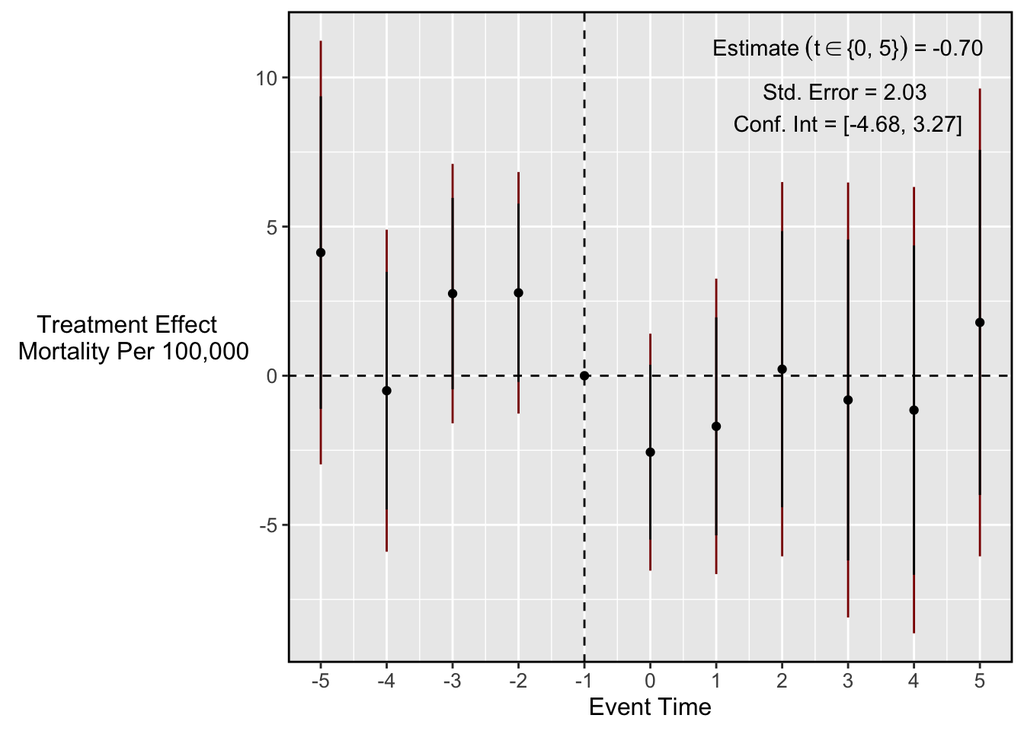

```r
# Make event study plots
# first add in the variables needed to run the CS model - timing group variable (treat_year)
# and county code needs to be numeric
mydata <- mydata %>%
  mutate(treat_year = if_else(yaca == 2014 & !is.na(yaca), 2014, 0),
         county_code = as.numeric(county_code),
         time_to_treat = if_else(Treat == 1, year - treat_year, 0))

# estimate CS models

# get the individual ATT(g,t) estimates
mod <- did::att_gt(
  yname = "crude_rate_20_64",
  tname = "year",
  idname = "county_code",
  gname = "treat_year",
  xformla =  NULL,
  data = mydata,
  panel = TRUE,
  control_group = "nevertreated",
  bstrap = TRUE,
  cband = TRUE,
  est_method = "reg",
  weightsname = "set_wt",
  # faster_mode = TRUE,
  base_period = "universal",
  biters = 25000
)

# confirm you get the same with OLS (standard errors differ because of bootstrap only)
cs_out <- mod

ols_out <- feols(crude_rate_20_64 ~ i(time_to_treat, Treat, ref = -1) | county_code + year,
      data = mydata,
      cluster = ~county_code,
      weights = ~set_wt)

# get the Rambachan/Roth confidence interval
# first save our aggregate event study estimates
es <- did::aggte(
  mod,
  type = "dynamic",
  min_e = -5,
  max_e = 0,
  bstrap = TRUE,
  biters = 25000
)

# source the honest_did code made to fit our estimates
source(here::here('5_honestdid.R'))

# get robust CI
robust_ci <- honest_did(es = es, type = "relative_magnitude")$robust_ci

# get the aggregate value for e = 0:5
agg <- mod %>%
  aggte(type = "dynamic", min_e = 0, max_e = 5,
        bstrap = TRUE, biters = 25000)

# make labels for the estimate, std error, and confidence intervals
label1 <-  paste0("Estimate~(t %in% '{0, 5}')~'='~'", scales::number(agg$overall.att, accuracy = 0.01), "'")

label2 <- paste0("Std. Error = ", scales::number(agg$overall.se, 0.01), " \n",
                 "Conf. Int = [", scales::number(agg$overall.att - 1.96*agg$overall.se, 0.01), ", ",
                 scales::number(agg$overall.att + 1.96*agg$overall.se, 0.01), "]")

# make event study plot for Figure
mod %>%
  # Aggregate in event time ("dynamic")
  aggte(type = "dynamic", biters = 25000) %>%
  # get the two confidence intervals
  broom::tidy(conf.int = TRUE) %>%
  # plot
  ggplot(aes(x = event.time, y = estimate)) +
  geom_linerange(aes(ymin = conf.low, ymax = conf.high), color = "darkred") +
  geom_linerange(aes(ymin = point.conf.low, ymax = point.conf.high)) +
  geom_point() +
  geom_vline(xintercept = -1, linetype = "dashed") +
  geom_hline(yintercept = 0, linetype = "dashed") +
  scale_x_continuous(breaks = -5:5) +
  annotate("text", x = 3, y = 11, label = label1, parse = TRUE) +
  annotate("text", x = 3, y = 9, label = label2) +
  labs(x = "Event Time", y = "Treatment Effect \n Mortality Per 100,000") +
  theme(axis.title.y = element_text(hjust = 0.5, vjust = 0.5, angle = 360),
        strip.text = element_text(size = 14),
        panel.border = element_rect(color = "black", fill = NA, linewidth = 1),
        legend.title = element_blank(),
        axis.title = element_text(size = 12),
        axis.text = element_text(size = 10))
```

## 4.2 QUESTION: Based on the above event study plot, are any of the estimated treatment effects for specific relative time periods statistically significant? Be specific about which relative time periods 𝑗={0,1,2,3,4,5} have estimated effects that are/aren’t significant, and explain how you can determine this from the above plot.

## Event study estimates in the pre-periods

Multiple time periods in the pre-treatment period also allow us to perform a falsification test that informs the plausibility of the parallel trends and no anticipation assumptions, which implies every $ATT(t)$ before time period $g$ is equal to 0. We now refer to the *ATT*s between the reference period $t=g-1$ and $t=g-k$ going back *k* periods prior to the treatment as $\tau_{-k}$, to distinguish these “pre-trends” from actual treatment effects during the treatment period.

Thus the internal validity of an event study depends in large part on finding small estimates of $\tau_{-k}$. Indeed, from the event study plot we can see that none of these estimates are statistically significant. But that doesn’t mean that parallel trends holds; parallel trends is inherently untestable, as we never observe the counterfactual outcome change for treated units. In this case, we fail to reject the null hypothesis that the pre-trend estimate equals zero (individually or jointly). But the pre-trend estimates also trend to be positive and larger in magnitude than many of the post-period estimates. What do we make of these pre-trends, and what does it say about the viability of the parallel trends assumption?

Baker et al (2025) caution against relying solely on an eye-test of whether pre-trends are meaningfully different from zero. A better approach begins with finding the maximum deviation from parallel trends observed in the pre-period. Next, find how large a deviation could occur in the post-period (relative to the maximum pre-period violation) before a significant *ATT* breaks down. These methods have been formalized by Rambachan and Roth (2023) and can be implemented using the `HonestDID` R package.

## Estimation and aggregating effects across time in event-studies

An event study can be understood as a collection of simple $2 \times 2$ DID comparisons, one for each time period relative to treatment. Rather than estimating each of these separately, researchers can recover all period-specific treatment effects in a single step by running a two-way fixed effects (TWFE) regression with unit fixed effects, time fixed effects, and interactions between the treatment group indicator and time dummies. One period, typically the period immediately before treatment, is omitted to serve as the baseline, so each coefficient measures the treatment effect relative to that reference period. This splits the coefficients into pre- and post-treatment groups, as in the following PRF:

$$\begin{align}
Y_{i,t} = \theta_t + \eta_i + \sum_{k=1}^{g=-2} \beta_k^{pre} 1\{G_i = g\} \cdot 1\{t = k\} + \sum_{k=g}^{T} \beta_k^{post} 1\{G_i = g\} \cdot 1\{t = k\} + \epsilon_{it} \tag{4.2}
\end{align}$$

Estimates from equation (4.2) produces the same point estimates as the underlying $2 \times 2$ DID calculations from equation (4.1), along with standard errors and confidence intervals.

An additional issue in event study inference, however, involves the fact that we are now estimating many treatment effect parameters. Thus, when we compare across event study estimates, we are conducting many hypothesis tests, and the usual normal critical values used to construct confidence intervals do not account for these. Asymptotically correct inferences about the entire event study curve require “inflating” critical values to perform a multiple hypothesis test adjustment.

A related issue arises when aggregating these period-specific effects into a single summary measure, such as the average treatment effect across post-treatment periods. While this can be computed directly by averaging the event study estimates, a common shortcut is to estimate a simpler regression with a single treatment indicator, in place of multiple event study dummies. This approach does not generally recover the same parameter, because it averages outcomes across all pre- and post-treatment periods, rather than comparing each post-treatment period to a consistent baseline. As a result, the estimate may be biased if the parallel trends assumption does not hold uniformly across all pre-treatment periods.

## Covariates in event studies

Another advantage of seeing event studies as collections of $2 \times 2$ building blocks is that all the tools for incorporating covariates immediately apply to each event study estimate. The key difference is that, instead of comparing short changes over one period, we now compare “long differences:” the change in outcomes from the baseline period (just before treatment) to each later time period. To incorporate covariates, researchers can use familiar approaches such RA, IPW, or DR. Each of these methods adjusts for differences in observable characteristics between treated and untreated units, but they do so in slightly different ways: RA models outcomes directly, IPW re-weights observations based on treatment probabilities, and DR combines both approaches. In an event study, these adjustments must be applied separately for each time period.

Note that the same concerns that arise in simpler DID settings, such as model misspecification or inappropriate controls, still apply, and can become even more complicated with multiple time periods.

# 5 Looking ahead

In this lesson we have formalized the research design for identifying and estimating average treatment effects for $2 \times 2$ DID building blocks and for $2 \times T$ simple event studies. Next, we will build on this foundation to allow for the timing of the treatment to differ between units in a *staggered DID design*, as is the case with Medicaid expansion where states expanded in different years.